# 8. Ajuste de Hiperparâmetros: Previsão de rotatividade de clientes de Telecomunicações

# **Introdução**

O ajuste dos hiperparâmetros pode melhorar o desempenho do algoritmo Random Forest. Segundo Probst et al. (2019), nem todos os hiperparâmetros são “parâmetros de ajuste”. Por isso, é necessário escolher bem os parâmetros a serem ajustados, assim como seus respectivos valores.

Cada “parâmetro de ajuste” tem uma função específica. Por exemplo, nodesize controla a estrutura de cada árvore individual, ntree controla a estrutura e o tamanho da floresta e mtry controla o nível de aleatoriedade (PROBST et al., 2019).

Os hiperparâmtros que serão ajustados neste projeto são: ntree, mtry, nodesize e samplesize.

**Ntree:** Número de árvores. Este é um parâmetro que normalmente não é ajustado, porém deve ser grande o suficiente (PROBST; BOULESTEIX, 2017). Um grande número tende a aumentar o poder preditivo do modelo, mas isso acontece a taxas decrescentes (ELLIS, 2022b).

O ntree incial é igual a 100. No ajuste, será simulado valores de 200, 300, 400, 500 e 700. De acordo com Ellis(2022c), este deve ser o primeiro a parâmetro a ser ajustado. Portanto, esta recomendação será seguida aqui.

**Mtry:** Refere-se a quantas variáveis são selecionadas aleatoriamente em uma divisão de nó. Este parâmetro controla quanta aleatoriedade é adicionada no processo de criação da árvore de decisão.Isso é importante para garantir que todas as árvores de decisão treinadas não sejam iguais (ELLIS, 2022a).

De acordo com Probst et al. (2019), um valor padrão para classificação é a raiz quadrada no número de variáveis no conjunto de dados. Tem-se 20 preditoras no modelo Radom Forest 4 (modelo inicial). A raiz quadrada de 20 é aprox. 4,47. Logo serão testados os valores 3, 4, 5 e 6.

**Nodesize:** Especifica o número mínimo de observações em um nó terminal. Ele controla a complexidade das arvores e está relacionado com a sua profundidade. Pois um nodesize menor permite arvores mais profundas e complexas.

O valor padrão é 1 para classificação (PROBST et al., 2019). Porém em grandes conjuntos de dados aumentar o nodesize pode ser uma boa estratégia já que diminui o tempo computacional sem a perda do desempenho de previsão (Segal, 2004).

O nodesize inicial é igual 50. Como este conjunto de dados é grande será simulado valores a cima e a baixo de 50.

**Samplesize:** Representa o tamanho da amostra, ou seja, o número de observações extraídas para treinamento de cada árvore.

Ao reduzir esse tamanho, cada árvore será treinada com menos dados, consequentemente, elas serão mais diversas entre si (PROBST et al., 2019). Isso aumenta a precisão geral do modelo, pois ajuda o algoritmo a capturar padrões nos dados.

Entretanto, a precisão de cada árvore diminui. Além disso, a redução de samplesize impacta negativamente na estabilidade individual de cada. Portanto, a escolha do valor de sample size é trade-off entre precisão e estabilidade (PROBST et al., 2019).

# Execução do Ajuste de Hiperparâmetros

O ajuste dos Hiperparâmetros será feito de três maneiras.

# Carregar os pacotes

```r
library(dplyr)
library(lattice) #necessária para usar o pacote caret
library(caret) #Fazer avaliação dos modelos, padronizar os dados etc
library(randomForest)
```

```r
library(ggplot2)
library(ROCR)#para fazer a curva ROC
library(pROC)
```

# Base de dados

```r
setwd("C:/0.Projetos/2.Telecom_customer_(Churn)/Scripts")
dados_treino1 <- read.csv("dados_treino1.csv")
dados_teste1 <- read.csv("dados_teste1.csv")
```

# Ajuste automático 1 (NÃO DEU CERTO)

Ajuste automático utilizando o pacote Caret

### Criar uma nova base de dados

```r
## Selecionar variaveis
#rf4_var_t <- dados_treino1 %>%
#  select(churn, eqpdays, months, change_mou, totrev,
#         mou_cvce_Mean, avgqty, rev_Mean, avgmou,
#         totcalls, adjqty, adjmou, totmrc_Mean, totmou,
#         peak_vce_Mean, plcd_vce_Mean, complete_Mean, unan_vce_Mean,
#         avg6rev, drop_vce_Mean, ovrmou_Mean)


# Converter a variável de resposta para um fator
#rf4_var_t$churn <- as.factor(rf4_var_t$churn)

# Converter a variável de resposta para um fator (XO e X1)
#rf4_var_t$churn <- as.factor(make.names(as.character(rf4_var_t$churn)))
```

### Otimizar Hiperparâmetros

```r
#control <- trainControl(
#  method = "cv",
#  number = 10,
#  savePredictions = TRUE,
#  classProbs = TRUE
#)

#hyper_parameters <- expand.grid(
#  mtry = c(6, 7, 8),
#  nodesize = c(5, 10, 15)
#)


#model1 <- train(
#  y = rf4_var_t[,1],
#  x = rf4_var_t[, -1],
#  method = "rf",
#  trControl = control,
#  ntree = c(50, 100, 200),
#  tuneGrid= hyper_parameters
#)
```

# Função para o cálculo da previsão e das métricas

Esta função automatiza a previsão e as métricas dos modelos de ajuste

```r
# Função
f_rf4 <- function(var) {
  pred_rf4 <- predict(var, newdata = dados_teste1, type = "response")
  prob_rf4 <- ifelse(pred_rf4 >= 0.4, 1, 0)
  prob_rf4 <- as.factor(prob_rf4)
  verdadeiro <- factor(dados_teste1$churn)
  matrix_rf4 <- confusionMatrix(prob_rf4, verdadeiro, positive = "1")
  precision_rf4 <- matrix_rf4$byClass["Pos Pred Value"]
  recall_rf4 <- matrix_rf4$byClass["Sensitivity"]
  f1_score_rf4 <- 2 * (precision_rf4 * recall_rf4) / (precision_rf4 + recall_rf4)
  ks_rf4 <- ks.test(pred_rf4, as.numeric(verdadeiro))
  roc_rf4 <- roc(dados_teste1$churn, pred_rf4)
  auc_valor <- auc(roc_rf4)
  cat("Precision:", precision_rf4, "\n")
  cat("Recall:", recall_rf4, "\n")
  cat("F1-Score:", f1_score_rf4, "\n")
  cat("Valor do KS:", ks_rf4$statistic, "\n")
  cat("AUC:", auc_valor, "\n")
  print(matrix_rf4$table)

}
```

# Ajuste manual 1a

Testar ntree=200

```r
# Ajuste 1a
### ntree=200
set.seed(123)
rf4_ajuste1a <- randomForest(churn ~ eqpdays + months + change_mou + totrev +
                      mou_cvce_Mean + avgqty + rev_Mean + avgmou +
                      totcalls + adjqty+ adjmou + totmrc_Mean + totmou +
                      peak_vce_Mean + plcd_vce_Mean + complete_Mean + unan_vce_Mean +
                      avg6rev + drop_vce_Mean + ovrmou_Mean , data= dados_treino1,
                      importance= T,cv=10,  ntree = 200,
                    mtry = 8, nodesize= 50, type = "classification")
```

```r
result_rf4_ajuste1a<-f_rf4(rf4_ajuste1a)
```

```
## Precision: 0.549729
## Recall: 0.8203279
## F1-Score: 0.6583056
## Valor do KS: 1
## AUC: 0.6595368
##           Reference
## Prediction    0    1
##          0 1857  822
##          1 3074 3753
```

```r
#Resultados:
#Precision: 0.549729
#Recall: 0.8203279
#F1-Score: 0.6583056
#Valor do KS: 1
#AUC: 0.6595368
```

# Ajuste manual 1b

Testar ntree=300

```r
# Ajuste 1b
### ntree=300
set.seed(123)
rf4_ajuste1b <- randomForest(churn ~ eqpdays + months + change_mou + totrev +
                               mou_cvce_Mean + avgqty + rev_Mean + avgmou +
                               totcalls + adjqty+ adjmou + totmrc_Mean + totmou +
                               peak_vce_Mean + plcd_vce_Mean + complete_Mean + unan_vce_Mean +
                               avg6rev + drop_vce_Mean + ovrmou_Mean ,
                             data= dados_treino1, importance= T,cv=10, ntree = 300,
                             mtry = 8, nodesize= 50, type = "classification")
```

```r
result_rf4_ajuste1b<-f_rf4(rf4_ajuste1b)
```

```
## Precision: 0.5517949
## Recall: 0.8231694
## F1-Score: 0.6607018
## Valor do KS: 1
## AUC: 0.6608051
##           Reference
## Prediction    0    1
##          0 1872  809
##          1 3059 3766
```

```r
#Resultados:
#Precision: 0.5517949
#Recall: 0.8231694
#F1-Score: 0.6607018
#Valor do KS: 1
#AUC: 0.6608051
```

# Ajuste manual 1c

Testar ntree=400

```r
# Ajuste 1c
### ntree=400
set.seed(123)
rf4_ajuste1c <- randomForest(churn ~ eqpdays + months + change_mou + totrev +
                               mou_cvce_Mean + avgqty + rev_Mean + avgmou +
                               totcalls + adjqty+ adjmou + totmrc_Mean + totmou +
                               peak_vce_Mean + plcd_vce_Mean + complete_Mean + unan_vce_Mean +
                               avg6rev + drop_vce_Mean + ovrmou_Mean , data= dados_treino1,
                             importance= T, cv=10, ntree = 400,
                             mtry = 8, nodesize= 50, type = "classification")
```

```r
result_rf4_ajuste1c<-f_rf4(rf4_ajuste1c)
```

```
## Precision: 0.5514921
## Recall: 0.8240437
## F1-Score: 0.6607659
## Valor do KS: 1
## AUC: 0.6614021
##           Reference
## Prediction    0    1
##          0 1865  805
##          1 3066 3770
```

```r
#Resultados:
#Precision: 0.5514921
#Recall: 0.8240437
#F1-Score: 0.6607659
#Valor do KS: 1
#AUC: 0.6614021
```

# Ajuste manual 1 d

Testar ntree=500

```r
# Ajuste 1d
### ntree=500
set.seed(123)
rf4_ajuste1d <- randomForest(churn ~ eqpdays + months + change_mou + totrev +
                               mou_cvce_Mean + avgqty + rev_Mean + avgmou +
                               totcalls + adjqty+ adjmou + totmrc_Mean + totmou +
                               peak_vce_Mean + plcd_vce_Mean + complete_Mean + unan_vce_Mean +
                               avg6rev + drop_vce_Mean + ovrmou_Mean , data= dados_treino1,
                             importance= T, cv=10, ntree = 500,
                             mtry = 8, nodesize= 50, type = "classification")
```

```r
result_rf4_ajuste1d<-f_rf4(rf4_ajuste1d)
```

```
## Precision: 0.5522737
## Recall: 0.8255738
## F1-Score: 0.6618188
## Valor do KS: 1
## AUC: 0.6618625
##           Reference
## Prediction    0    1
##          0 1869  798
##          1 3062 3777
```

```r
#Resultados:
#Precision: 0.5522737
#Recall: 0.8255738
#F1-Score: 0.6618188
#Valor do KS: 1
#AUC: 0.6618625
```

# Ajuste manual 1e

Testar ntree=700

```r
# Ajuste 1e
### ntree=700
set.seed(123)
rf4_ajuste1e <- randomForest(churn ~ eqpdays + months + change_mou + totrev +
                               mou_cvce_Mean + avgqty + rev_Mean + avgmou +
                               totcalls + adjqty+ adjmou + totmrc_Mean + totmou +
                               peak_vce_Mean + plcd_vce_Mean + complete_Mean + unan_vce_Mean +
                               avg6rev + drop_vce_Mean + ovrmou_Mean , data= dados_treino1,
                             importance= T, cv=10, ntree = 700,
                             mtry = 8, nodesize= 50, type = "classification")
```

```r
result_rf4_ajuste1e<-f_rf4(rf4_ajuste1e)
```

```
## Precision: 0.5507162
## Recall: 0.8236066
## F1-Score: 0.6600683
## Valor do KS: 1
## AUC: 0.6627349
##           Reference
## Prediction    0    1
##          0 1857  807
##          1 3074 3768
```

```r
#Resultados:
#Precision: 0.5507162
#Recall: 0.8236066
#F1-Score: 0.6600683
#Valor do KS: 1
#AUC: 0.6627349
```

# Resultado parcial 1

O modelo escolhido foi `Ajuste 1d`com `ntree`=500

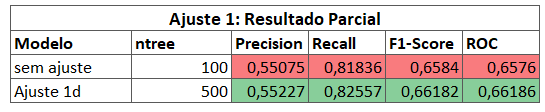

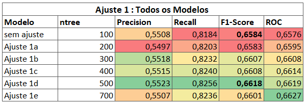

# Ajuste manual 2a

Testar mtry= 3

```r
# Ajuste 2a
#São 20 preditores
#Raiz quadrada de 20 é 4,47
#Um terço de 20 é 6,667
#log na base 2 de 20 é 4,322

#mtry= 3
set.seed(123)
rf4_ajuste2a <- randomForest(churn ~ eqpdays + months + change_mou + totrev +
                               mou_cvce_Mean + avgqty + rev_Mean + avgmou +
                               totcalls + adjqty+ adjmou + totmrc_Mean + totmou +
                               peak_vce_Mean + plcd_vce_Mean + complete_Mean + unan_vce_Mean +
                               avg6rev + drop_vce_Mean + ovrmou_Mean , data= dados_treino1,
                             importance= T,cv=10, ntree = 500,
                             mtry = 3, nodesize= 50, type = "classification")
```

```r
result_rf4_ajuste2a<-f_rf4(rf4_ajuste2a)
```

```
## Precision: 0.5491008
## Recall: 0.8408743
## F1-Score: 0.664364
## Valor do KS: 1
## AUC: 0.6635467
##           Reference
## Prediction    0    1
##          0 1772  728
##          1 3159 3847
```

```r
#Resultados
#Precision: 0.5491008
#Recall: 0.8408743
#F1-Score: 0.664364
#Valor do KS: 1
#AUC: 0.6635467
```

# Ajuste manual 2b

Testar mtry= 4

```r
# Ajuste 2b
#São 20 preditores
#Raiz quadrada de 20 é 4,47
#Um terço de 20 é 6,667
#log na base 2 de 20 é 4,322

#mtry= 4
set.seed(123)
rf4_ajuste2b <- randomForest(churn ~ eqpdays + months + change_mou + totrev +
                               mou_cvce_Mean + avgqty + rev_Mean + avgmou +
                               totcalls + adjqty+ adjmou + totmrc_Mean + totmou +
                               peak_vce_Mean + plcd_vce_Mean + complete_Mean + unan_vce_Mean +
                               avg6rev + drop_vce_Mean + ovrmou_Mean ,
                             data= dados_treino1, importance= T,cv=10, ntree = 500,
                             mtry = 4, nodesize= 50, type = "classification")
```

```r
result_rf4_ajuste2b<-f_rf4(rf4_ajuste2b)
```

```
## Precision: 0.5501933
## Recall: 0.8397814
## F1-Score: 0.6648209
## Valor do KS: 1
## AUC: 0.6623283
##           Reference
## Prediction    0    1
##          0 1790  733
##          1 3141 3842
```

```r
#Resultado:
#Precision: 0.5501933
#Recall: 0.8397814
#F1-Score: 0.6648209
#Valor do KS: 1
#AUC: 0.6623283
```

# Ajuste manual 2c

Testar mtry= 5

```r
# Ajuste 2c
#São 20 preditores
#Raiz quadrada de 20 é 4,47
#Um terço de 20 é 6,667
#log na base 2 de 20 é 4,322

#mtry= 5
set.seed(123)
rf4_ajuste2c <- randomForest(churn ~ eqpdays + months + change_mou + totrev +
                               mou_cvce_Mean + avgqty + rev_Mean + avgmou +
                               totcalls + adjqty+ adjmou + totmrc_Mean + totmou +
                               peak_vce_Mean + plcd_vce_Mean + complete_Mean + unan_vce_Mean +
                               avg6rev + drop_vce_Mean + ovrmou_Mean ,
                             data= dados_treino1, importance= T, cv=10, ntree = 500,
                             mtry = 5, nodesize= 50, type = "classification")
```

```r
result_rf4_ajuste2c<-f_rf4(rf4_ajuste2c)
```

```
## Precision: 0.5515695
## Recall: 0.8334426
## F1-Score: 0.6638231
## Valor do KS: 1
## AUC: 0.6639341
##           Reference
## Prediction    0    1
##          0 1831  762
##          1 3100 3813
```

```r
#Resultado:
#Precision: 0.5515695
#Recall: 0.8334426
#F1-Score: 0.6638231
#Valor do KS: 1
#AUC: 0.6639341
```

# Ajuste manual 2d

Testar mtry= 6

```r
# Ajuste 2d
#São 20 preditores
#Raiz quadrada de 20 é 4,47
#Um terço de 20 é 6,667
#log na base 2 de 20 é 4,322

#mtry= 6
set.seed(123)
rf4_ajuste2c <- randomForest(churn ~ eqpdays + months + change_mou + totrev +
                               mou_cvce_Mean + avgqty + rev_Mean + avgmou +
                               totcalls + adjqty+ adjmou + totmrc_Mean + totmou +
                               peak_vce_Mean + plcd_vce_Mean + complete_Mean + unan_vce_Mean +
                               avg6rev + drop_vce_Mean + ovrmou_Mean ,
                             data= dados_treino1, importance= T, cv=10, ntree = 500,
                             mtry = 6, nodesize= 50, type = "classification")
```

```r
result_rf4_ajuste2c<-f_rf4(rf4_ajuste2c)
```

```
## Precision: 0.5515134
## Recall: 0.8284153
## F1-Score: 0.6621822
## Valor do KS: 1
## AUC: 0.6634432
##           Reference
## Prediction    0    1
##          0 1849  785
##          1 3082 3790
```

```r
#Resultado:
#Precision: 0.5515134
#Recall: 0.8284153
#F1-Score: 0.6621822
#Valor do KS: 1
#AUC: 0.6634432
```

# Resultado Parcial 2

O modelo escolhido foi `Ajuste 2c` com `mtry`=5. Esta é a segunda melhor opção de modelo. Pois o modelo `Ajuste 2b` tinha o maior F1-Score, porém tinha um precision pior que o modelo inicial (sem ajuste). E, apesar da métrica de avaliação ser o F1, é desejado aumentar o precision.

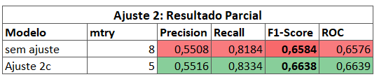

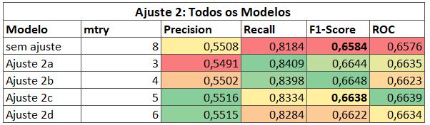

# Ajuste manual 3a

Testar nodesize=40

```r
# Ajuste 3a
#nodesize=40
set.seed(123)
rf4_ajuste3a <- randomForest(churn ~ eqpdays + months + change_mou + totrev +
                               mou_cvce_Mean + avgqty + rev_Mean + avgmou +
                               totcalls + adjqty+ adjmou + totmrc_Mean + totmou +
                               peak_vce_Mean + plcd_vce_Mean + complete_Mean + unan_vce_Mean +
                               avg6rev + drop_vce_Mean + ovrmou_Mean ,
                             data= dados_treino1, importance= T, cv=10, ntree = 500,
                             mtry = 5, nodesize= 40, type = "classification")
```

```r
result_rf4_ajuste3a<-f_rf4(rf4_ajuste3a)
```

```
## Precision: 0.5496746
## Recall: 0.8308197
## F1-Score: 0.6616188
## Valor do KS: 1
## AUC: 0.6631885
##           Reference
## Prediction    0    1
##          0 1817  774
##          1 3114 3801
```

```r
#Resultado:
#Precision: 0.5496746
#Recall: 0.8308197
#F1-Score: 0.6616188
#Valor do KS: 1
#AUC: 0.6631885
```

# Ajuste manual 3b

Testar nodesize=60

```r
# Ajuste 3b
#nodesize=60
set.seed(123)
rf4_ajuste3b <- randomForest(churn ~ eqpdays + months + change_mou + totrev +
                               mou_cvce_Mean + avgqty + rev_Mean + avgmou +
                               totcalls + adjqty+ adjmou + totmrc_Mean + totmou +
                               peak_vce_Mean + plcd_vce_Mean + complete_Mean + unan_vce_Mean +
                               avg6rev + drop_vce_Mean + ovrmou_Mean ,
                             data= dados_treino1, importance= T, cv=10, ntree = 500,
                             mtry = 5, nodesize= 60, type = "classification")
```

```r
result_rf4_ajuste3b<-f_rf4(rf4_ajuste3b)
```

```
## Precision: 0.5506038
## Recall: 0.8371585
## F1-Score: 0.6642962
## Valor do KS: 1
## AUC: 0.6648523
##           Reference
## Prediction    0    1
##          0 1805  745
##          1 3126 3830
```

```r
#Resultado:
#Precision: 0.5506038
#Recall: 0.8371585
#F1-Score: 0.6642962
#Valor do KS: 1
#AUC: 0.6648523
```

# Ajuste manual 3c

Testar nodesize=80

```r
# Ajuste 3c
#nodesize=80
set.seed(123)
rf4_ajuste3c <- randomForest(churn ~ eqpdays + months + change_mou + totrev +
                               mou_cvce_Mean + avgqty + rev_Mean + avgmou +
                               totcalls + adjqty+ adjmou + totmrc_Mean + totmou +
                               peak_vce_Mean + plcd_vce_Mean + complete_Mean + unan_vce_Mean +
                               avg6rev + drop_vce_Mean + ovrmou_Mean ,
                             data= dados_treino1, importance= T, cv=10, ntree = 500,
                             mtry = 5, nodesize= 80, type = "classification")
```

```r
result_rf4_ajuste3c<-f_rf4(rf4_ajuste3c)
```

```
## Precision: 0.5524002
## Recall: 0.8375956
## F1-Score: 0.6657401
## Valor do KS: 1
## AUC: 0.6656066
##           Reference
## Prediction    0    1
##          0 1826  743
##          1 3105 3832
```

```r
#Resultado
#Precision: 0.5524002
#Recall: 0.8375956
#F1-Score: 0.6657401
#Valor do KS: 1
#AUC: 0.6656066
```

# Ajuste manual 3d

Testar nodesize=100

```r
# Ajuste 3d
#nodesize=100
set.seed(123)
rf4_ajuste3d <- randomForest(churn ~ eqpdays + months + change_mou + totrev +
                               mou_cvce_Mean + avgqty + rev_Mean + avgmou +
                               totcalls + adjqty+ adjmou + totmrc_Mean + totmou +
                               peak_vce_Mean + plcd_vce_Mean + complete_Mean + unan_vce_Mean +
                               avg6rev + drop_vce_Mean + ovrmou_Mean ,
                             data= dados_treino1, importance= T, cv=10, ntree = 500,
                             mtry = 5, nodesize= 100, type = "classification")
```

```r
result_rf4_ajuste3d<-f_rf4(rf4_ajuste3d)
```

```
## Precision: 0.5517489
## Recall: 0.8413115
## F1-Score: 0.6664358
## Valor do KS: 1
## AUC: 0.6658534
##           Reference
## Prediction    0    1
##          0 1804  726
##          1 3127 3849
```

# Resultado Parcial 3

O modelo escolhido foi `Ajuste 3c` com `nodesize`=80. Esta é a segunda melhor opção de modelo. Pois o modelo `Ajuste 3d` tinha o maior F1-Score, porém tinha o segundo melhor precision. E, apesar da métrica de avaliação ser o F1, é desejado aumentar o precision.

[figure not shown]

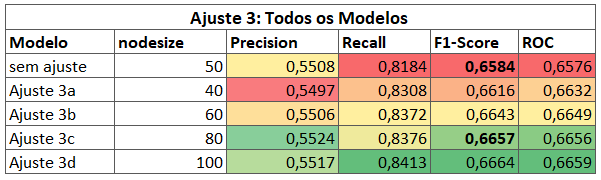

# Ajuste manual 4a

Testar samplesize= 1000

```r
# Ajuste 4a
#valor padrão é 63,25% do conjunto de treinamento
#Conjunto de treino de 44363 observações
# 63,25% * 44363 = 28.059,5975

#samplesize= 1000

set.seed(123)
rf4_ajuste4a <- randomForest(churn ~ eqpdays + months + change_mou + totrev +
                               mou_cvce_Mean + avgqty + rev_Mean + avgmou +
                               totcalls + adjqty+ adjmou + totmrc_Mean + totmou +
                               peak_vce_Mean + plcd_vce_Mean + complete_Mean + unan_vce_Mean +
                               avg6rev + drop_vce_Mean + ovrmou_Mean ,
                             data= dados_treino1, importance= T, cv=10, ntree = 500,
                             mtry = 5, nodesize= 100, type = "classification", sampsize=1000 )
```

```r
result_rf4_ajuste4a<-f_rf4(rf4_ajuste4a)
```

```
## Precision: 0.5319232
## Recall: 0.8904918
## F1-Score: 0.6660128
## Valor do KS: 1
## AUC: 0.6462653
##           Reference
## Prediction    0    1
##          0 1346  501
##          1 3585 4074
```

# Ajuste manual 4b

Testar samplesize= 10.000

```r
# Ajuste 4b
#valor padrão é 63,25% do conjunto de treinamento
#Conjunto de treino de 44363 observações
# 63,25% * 44363 = 28.059,5975

#samplesize= 10.000

set.seed(123)
rf4_ajuste4b <- randomForest(churn ~ eqpdays + months + change_mou + totrev +
                               mou_cvce_Mean + avgqty + rev_Mean + avgmou +
                               totcalls + adjqty+ adjmou + totmrc_Mean + totmou +
                               peak_vce_Mean + plcd_vce_Mean + complete_Mean + unan_vce_Mean +
                               avg6rev + drop_vce_Mean + ovrmou_Mean ,
                             data= dados_treino1, importance= T, cv=10, ntree = 500,
                             mtry = 5, nodesize= 100, type = "classification", sampsize=10000 )
```

```r
result_rf4_ajuste4b<-f_rf4(rf4_ajuste4b)
```

```
## Precision: 0.5463117
## Recall: 0.8612022
## F1-Score: 0.6685331
## Valor do KS: 1
## AUC: 0.6642311
##           Reference
## Prediction    0    1
##          0 1659  635
##          1 3272 3940
```

# Ajuste 4c

Testar samplesize= 15.000

```r
# Ajuste 4c
#valor padrão é 63,25% do conjunto de treinamento
#Conjunto de treino de 44363 observações
# 63,25% * 44363 = 28.059,5975

#samplesize= 15.000

set.seed(123)
rf4_ajuste4c <- randomForest(churn ~ eqpdays + months + change_mou + totrev +
                               mou_cvce_Mean + avgqty + rev_Mean + avgmou +
                               totcalls + adjqty+ adjmou + totmrc_Mean + totmou +
                               peak_vce_Mean + plcd_vce_Mean + complete_Mean + unan_vce_Mean +
                               avg6rev + drop_vce_Mean + ovrmou_Mean ,
                             data= dados_treino1, importance= T, cv=10, ntree = 500,
                             mtry = 5, nodesize= 100, type = "classification", sampsize=15000 )
```

```r
result_rf4_ajuste4c<-f_rf4(rf4_ajuste4c)
```

```
## Precision: 0.548926
## Recall: 0.8546448
## F1-Score: 0.6684903
## Valor do KS: 1
## AUC: 0.6656634
##           Reference
## Prediction    0    1
##          0 1718  665
##          1 3213 3910
```

# Ajuste manual 4d

Testar samplesize= 18.000

```r
# Ajuste 4d
#valor padrão é 63,25% do conjunto de treinamento
#Conjunto de treino de 44363 observações
# 63,25% * 44363 = 28.059,5975

#samplesize= 18.000

set.seed(123)
rf4_ajuste4d <- randomForest(churn ~ eqpdays + months + change_mou + totrev +
                               mou_cvce_Mean + avgqty + rev_Mean + avgmou +
                               totcalls + adjqty+ adjmou + totmrc_Mean + totmou +
                               peak_vce_Mean + plcd_vce_Mean + complete_Mean + unan_vce_Mean +
                               avg6rev + drop_vce_Mean + ovrmou_Mean ,
                             data= dados_treino1, importance= T, cv=10, ntree = 500,
                             mtry = 5, nodesize= 100, type = "classification", sampsize=18000 )
```

```r
result_rf4_ajuste4d<-f_rf4(rf4_ajuste4d)
```

```
## Precision: 0.5490526
## Recall: 0.855082
## F1-Score: 0.6687179
## Valor do KS: 1
## AUC: 0.666246
##           Reference
## Prediction    0    1
##          0 1718  663
##          1 3213 3912
```

# Ajuste manual 4e

Testar samplesize= 20.000

```r
# Ajuste 4e
#valor padrão é 63,25% do conjunto de treinamento
#Conjunto de treino de 44363 observações
# 63,25% * 44363 = 28.059,5975

#samplesize= 20.000

set.seed(123)
rf4_ajuste4e <- randomForest(churn ~ eqpdays + months + change_mou + totrev +
                               mou_cvce_Mean + avgqty + rev_Mean + avgmou +
                               totcalls + adjqty+ adjmou + totmrc_Mean + totmou +
                               peak_vce_Mean + plcd_vce_Mean + complete_Mean + unan_vce_Mean +
                               avg6rev + drop_vce_Mean + ovrmou_Mean ,
                             data= dados_treino1, importance= T, cv=10, ntree = 500,
                             mtry = 5, nodesize= 100, type = "classification", sampsize=20000 )
```

```r
result_rf4_ajuste4e<-f_rf4(rf4_ajuste4e)
```

```
## Precision: 0.5506857
## Recall: 0.8513661
## F1-Score: 0.6687843
## Valor do KS: 1
## AUC: 0.665698
##           Reference
## Prediction    0    1
##          0 1753  680
##          1 3178 3895
```

# Ajuste manual 4f

Testar samplesize= 25.000

```r
# Ajuste 4f
#valor padrão é 63,25% do conjunto de treinamento
#Conjunto de treino de 44363 observações
# 63,25% * 44363 = 28.059,5975

#samplesize= 25.000

set.seed(123)
rf4_ajuste4f <- randomForest(churn ~ eqpdays + months + change_mou + totrev +
                               mou_cvce_Mean + avgqty + rev_Mean + avgmou +
                               totcalls + adjqty+ adjmou + totmrc_Mean + totmou +
                               peak_vce_Mean + plcd_vce_Mean + complete_Mean + unan_vce_Mean +
                               avg6rev + drop_vce_Mean + ovrmou_Mean ,
                             data= dados_treino1, importance= T, cv=10, ntree = 500,
                             mtry = 5, nodesize= 100, type = "classification", sampsize=25000 )
```

```r
result_rf4_ajuste4f<-f_rf4(rf4_ajuste4f)
```

```
## Precision: 0.5496172
## Recall: 0.8474317
## F1-Score: 0.6667813
## Valor do KS: 1
## AUC: 0.6663572
##           Reference
## Prediction    0    1
##          0 1754  698
##          1 3177 3877
```

# Ajuste manual 4g

Testar samplesize= 28.000

```r
# Ajuste 4g
#valor padrão é 63,25% do conjunto de treinamento
#Conjunto de treino de 44363 observações
# 63,25% * 44363 = 28.059,5975

#samplesize= 28.000

set.seed(123)
rf4_ajuste4g <- randomForest(churn ~ eqpdays + months + change_mou + totrev +
                               mou_cvce_Mean + avgqty + rev_Mean + avgmou +
                               totcalls + adjqty+ adjmou + totmrc_Mean + totmou +
                               peak_vce_Mean + plcd_vce_Mean + complete_Mean + unan_vce_Mean +
                               avg6rev + drop_vce_Mean + ovrmou_Mean ,
                             data= dados_treino1, importance= T, cv=10, ntree = 500,
                             mtry = 5, nodesize= 100, type = "classification", sampsize=28059 )
```

```r
result_rf4_ajuste4f<-f_rf4(rf4_ajuste4f)
```

[output not shown]

# Resultado parcial 4

O modelo escolhido foi `Ajuste 4e` com `samplesize`=20.000. Esta é a segunda melhor opção de modelo. Pois o modelo `Ajuste 4g` tinha o maior F1-Score, porém tinha um precision pior que o modelo inicial (sem ajuste). E, apesar da métrica de avaliação ser o F1, é desejado aumentar o precision.

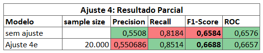

[figure not shown]

# Ajuste manual 5a

Testar maxdepth =20

```r
# Ajuste 5a
#Arvores mais profudas melhoram o desempenho preditivo
#Porém, aumentam as chances de overfitting
#Valores entre 1 e 20

#maxdepth =20

set.seed(123)
rf4_ajuste5a <- randomForest(churn ~ eqpdays + months + change_mou + totrev +
                               mou_cvce_Mean + avgqty + rev_Mean + avgmou +
                               totcalls + adjqty+ adjmou + totmrc_Mean + totmou +
                               peak_vce_Mean + plcd_vce_Mean + complete_Mean + unan_vce_Mean +
                               avg6rev + drop_vce_Mean + ovrmou_Mean ,
                             data= dados_treino1, importance= T, cv=10, ntree = 500,
                             mtry = 5, nodesize= 100, maxdepth =20, type = "classification", sampsize=20000 )
```

```r
result_rf4_ajuste5a<-f_rf4(rf4_ajuste5a)
```

```
## Precision: 0.5506857
## Recall: 0.8513661
## F1-Score: 0.6687843
## Valor do KS: 1
## AUC: 0.665698
##           Reference
## Prediction    0    1
##          0 1753  680
##          1 3178 3895
```

# Ajuste manual 5b

Testar maxdepth =15

```r
# Ajuste 5b

#Arvores mais profudas melhoram o desempenho preditivo
#Porém, aumentam as chances de overfitting
#Valores entre 1 e 20

#maxdepth =15

set.seed(123)
rf4_ajuste5b <- randomForest(churn ~ eqpdays + months + change_mou + totrev +
                               mou_cvce_Mean + avgqty + rev_Mean + avgmou +
                               totcalls + adjqty+ adjmou + totmrc_Mean + totmou +
                               peak_vce_Mean + plcd_vce_Mean + complete_Mean + unan_vce_Mean +
                               avg6rev + drop_vce_Mean + ovrmou_Mean ,
                             data= dados_treino1, importance= T, cv=10, ntree = 500,
                             mtry = 5, nodesize= 100, maxdepth =15, type = "classification", sampsize=20000 )
```

```r
result_rf4_ajuste5b<-f_rf4(rf4_ajuste5b)
```

```
## Precision: 0.5506857
## Recall: 0.8513661
## F1-Score: 0.6687843
## Valor do KS: 1
## AUC: 0.665698
##           Reference
## Prediction    0    1
##          0 1753  680
##          1 3178 3895
```

# Ajuste manual 5c

Testar maxdepth =100

```r
# Ajuste 5c

#Arvores mais profudas melhoram o desempenho preditivo
#Porém, aumentam as chances de overfitting
#Valores entre 1 e 20

#maxdepth =100

set.seed(123)
rf4_ajuste5c <- randomForest(churn ~ eqpdays + months + change_mou + totrev +
                               mou_cvce_Mean + avgqty + rev_Mean + avgmou +
                               totcalls + adjqty+ adjmou + totmrc_Mean + totmou +
                               peak_vce_Mean + plcd_vce_Mean + complete_Mean + unan_vce_Mean +
                               avg6rev + drop_vce_Mean + ovrmou_Mean ,
                             data= dados_treino1, importance= T, cv=10, ntree = 500,
                             mtry = 5, nodesize= 100, maxdepth =100, type = "classification", sampsize=20000 )
```

```r
result_rf4_ajuste5c<-f_rf4(rf4_ajuste5c)
```

```
## Precision: 0.5506857
## Recall: 0.8513661
## F1-Score: 0.6687843
## Valor do KS: 1
## AUC: 0.665698
##           Reference
## Prediction    0    1
##          0 1753  680
##          1 3178 3895
```

# Resultado Parcial 5

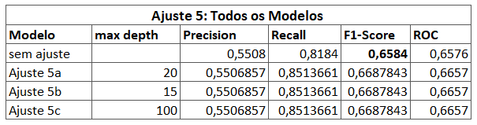

# Modelo escolhido no ajuste manual

O Modelo escolhido é `Ajuste 4e` com `ntree` = 500, `mtry` = 5, `nodesize`= 100 e `sampsize`=20000

# Ajuste automático 2

O ajuste terá como base o código deste [link](https://stackoverflow.com/questions/37514603/hyper-parameter-tuning-using-pure-ranger-package-in-r). Ele será feito utilizando a função ranger e um loop. Os hiperparâmetros a serem ajustados são: mtry, nodesize e ntree.

### Carregar os pacotes

```r
#Carregar os pacotes
#library(ranger)
#library(tune)
#library(tuneRanger)
#library(mlr)
```

### Escolhas dos hiperparâmetros e métrica

```r
# Escolhas dos parâmetros e métrica
#hyper_grid <- expand.grid(
#  mtry       = 3:15,
#  node_size  = 40:100,
#  num.trees = seq(300, 500, 600),
#  OOB_Error   = 0
#)
```

### Loop

```r
#system.time(
#  for(i in 1:nrow(hyper_grid)) {
#    # Treinar o modelo
#    rf <- ranger(
#      formula        = churn ~ eqpdays + months + change_mou + totrev + mou_cvce_Mean +
#        avgqty + rev_Mean + avgmou +
#        totcalls + adjqty+ adjmou + totmrc_Mean + totmou +
#        peak_vce_Mean + plcd_vce_Mean + complete_Mean + unan_vce_Mean +
#        avg6rev + drop_vce_Mean + ovrmou_Mean,
#      data           = dados_treino1,
#      num.trees      = hyper_grid$num.trees[i],
#      mtry           = hyper_grid$mtry[i],
#      min.node.size  = hyper_grid$node_size[i],
#      importance     = 'impurity',
#      probability    = TRUE  # Adicionado para obter probabilidades de classe
#    )
  # Adicionar erro OOB à grade
#    hyper_grid$OOB_Error[i] <- 1 - rf$prediction.error
#  }
#)
```

### Resultado

```r
#nrow(hyper_grid) # 793 modelos
#position = which.min(hyper_grid$OOB_Error)# 13
#head(hyper_grid[order(hyper_grid$OOB_Error),],10)

#Resultado:
#   mtry node_size num.trees OOB_Error
#13   15        40       300 0.7700599
#26   15        41       300 0.7701093
#65   15        44       300 0.7702436
#25   14        41       300 0.7702641
#91   15        46       300 0.7703602
#12    14        40       300 0.7703764
#104   15        47       300 0.7703810
#36    12        42       300 0.7703924
#64    14        44       300 0.7704041
#116   14        48       300 0.7704126
```

A seguir serão testados os 5 melhores resultados.

# Best model 1

Teste com mtry=15, nodesize=40 e ntree=300

```r
#Testar best model 1
#mtry=15
#node_size=40
#num.trees=300
best.model1<- randomForest(churn ~ eqpdays + months + change_mou + totrev + mou_cvce_Mean +
                            avgqty + rev_Mean + avgmou +
                            totcalls + adjqty+ adjmou + totmrc_Mean + totmou +
                            peak_vce_Mean + plcd_vce_Mean + complete_Mean + unan_vce_Mean +
                            avg6rev + drop_vce_Mean + ovrmou_Mean,
                          data = dados_treino1, importance= T, cv=10, ntree = 300,
                          mtry = 15, nodesize= 40, type = "classification")
```

```r
result_rf4_best_m1<-f_rf4(best.model1)
```

```
## Precision: 0.5492647
## Recall: 0.8163934
## F1-Score: 0.6567033
## Valor do KS: 1
## AUC: 0.6576097
##           Reference
## Prediction    0    1
##          0 1866  840
##          1 3065 3735
```

# Best model 2

Teste com mtry=15, nodesize=41 e ntree=300

```r
#Testar best model 2
#mtry=15
#node_size=41
#num.trees=300
best.model2<- randomForest(churn ~ eqpdays + months + change_mou + totrev + mou_cvce_Mean +
                             avgqty + rev_Mean + avgmou +
                             totcalls + adjqty+ adjmou + totmrc_Mean + totmou +
                             peak_vce_Mean + plcd_vce_Mean + complete_Mean + unan_vce_Mean +
                             avg6rev + drop_vce_Mean + ovrmou_Mean,
                           data = dados_treino1, importance= T, cv=10, ntree = 300,
                           mtry = 15, nodesize= 41, type = "classification")
```

```r
result_rf4_best_m2<-f_rf4(best.model2)
```

```
## Precision: 0.5478158
## Recall: 0.8113661
## F1-Score: 0.6540393
## Valor do KS: 1
## AUC: 0.6589519
##           Reference
## Prediction    0    1
##          0 1867  863
##          1 3064 3712
```

# Best model 3

```r
#Testar best model 3
#mtry=15
#node_size=44
#num.trees=300
best.model3<- randomForest(churn ~ eqpdays + months + change_mou + totrev + mou_cvce_Mean +
                             avgqty + rev_Mean + avgmou +
                             totcalls + adjqty+ adjmou + totmrc_Mean + totmou +
                             peak_vce_Mean + plcd_vce_Mean + complete_Mean + unan_vce_Mean +
                             avg6rev + drop_vce_Mean + ovrmou_Mean,
                           data = dados_treino1, importance= T, cv=10, ntree = 300,
                           mtry = 14, nodesize= 44, type = "classification")
```

```r
result_rf4_best_m3<-f_rf4(best.model3)
```

```
## Precision: 0.5492152
## Recall: 0.8183607
## F1-Score: 0.6573034
## Valor do KS: 1
## AUC: 0.6582701
##           Reference
## Prediction    0    1
##          0 1858  831
##          1 3073 3744
```

# Best model 4

Teste com mtry=14, nodesize=41 e ntree=300

```r
#Testar best model 4
#mtry=14
#node_size=41
#num.trees=300
best.model4<- randomForest(churn ~ eqpdays + months + change_mou + totrev + mou_cvce_Mean +
                             avgqty + rev_Mean + avgmou +
                             totcalls + adjqty+ adjmou + totmrc_Mean + totmou +
                             peak_vce_Mean + plcd_vce_Mean + complete_Mean + unan_vce_Mean +
                             avg6rev + drop_vce_Mean + ovrmou_Mean,
                           data = dados_treino1, importance= T, cv=10, ntree = 300,
                           mtry = 14, nodesize= 41, type = "classification")
```

```r
result_rf4_best_m4<-f_rf4(best.model4)
```

```
## Precision: 0.5507824
## Recall: 0.8155191
## F1-Score: 0.6575029
## Valor do KS: 1
## AUC: 0.6598808
##           Reference
## Prediction    0    1
##          0 1888  844
##          1 3043 3731
```

# Best model 5

Teste com mtry=15, nodesize=46 e ntree=300

```r
#Testar best model 5
#mtry=15
#node_size=46
#num.trees=300
best.model5<- randomForest(churn ~ eqpdays + months + change_mou + totrev + mou_cvce_Mean +
                             avgqty + rev_Mean + avgmou +
                             totcalls + adjqty+ adjmou + totmrc_Mean + totmou +
                             peak_vce_Mean + plcd_vce_Mean + complete_Mean + unan_vce_Mean +
                             avg6rev + drop_vce_Mean + ovrmou_Mean,
                           data = dados_treino1, importance= T, cv=10, ntree = 300,
                           mtry = 15, nodesize= 46, type = "classification")
```

```r
result_rf4_best_m5<-f_rf4(best.model5)
```

```
## Precision: 0.5506946
## Recall: 0.8144262
## F1-Score: 0.6570849
## Valor do KS: 1
## AUC: 0.659781
##           Reference
## Prediction    0    1
##          0 1891  849
##          1 3040 3726
```

# Resultado Parcial do Ajusto automático

[figure not shown]

[figure not shown]

# Resultado final

[figure not shown]

# Modelo Final e suas características

```r
set.seed(123)
final_model <- randomForest(churn ~ eqpdays + months + change_mou + totrev +
                               mou_cvce_Mean + avgqty + rev_Mean + avgmou +
                               totcalls + adjqty+ adjmou + totmrc_Mean + totmou +
                               peak_vce_Mean + plcd_vce_Mean + complete_Mean + unan_vce_Mean +
                               avg6rev + drop_vce_Mean + ovrmou_Mean ,
                             data= dados_treino1, importance= T, cv=10, ntree = 500,
                             mtry = 5, nodesize= 100, type = "classification", sampsize=20000 )
```

```r
result_final_model<-f_rf4(final_model)
```

```
## Precision: 0.5506857
## Recall: 0.8513661
## F1-Score: 0.6687843
## Valor do KS: 1
## AUC: 0.665698
##           Reference
## Prediction    0    1
##          0 1753  680
##          1 3178 3895
```

### Hiperparâmetros

- **ntree** = 500 -> Número de árvores
- **mtry** = 5 -> Número de variáveis selecionadas aleatoriamente em cada divisão
- **nodesize** = 100 -> Número mínimo de amostras dentro dos nós terminais
- **sampsize** =20000 -> Tamanho da amostra

### Preditoras

As variáveis preditoras do modelo final são:

### Importância das preditoras

```r
#Calcular a importancia
imp <- importance(final_model, type = 2) %>% desc()

DT::datatable(imp)
```

|  | IncNodePurity |
| --- | --- |
| eqpdays | -168.7460233023253 |
| months | -132.2914044688891 |
| change_mou | -103.6235629164846 |
| totrev | -71.9580320186333 |
| mou_cvce_Mean | -73.42842376069032 |
| avgqty | -57.71864935601081 |
| rev_Mean | -62.24343554961687 |
| avgmou | -55.91909322955455 |
| totcalls | -50.55990787597472 |
| adjqty | -48.81841902928993 |

[output cut: 10 more lines]

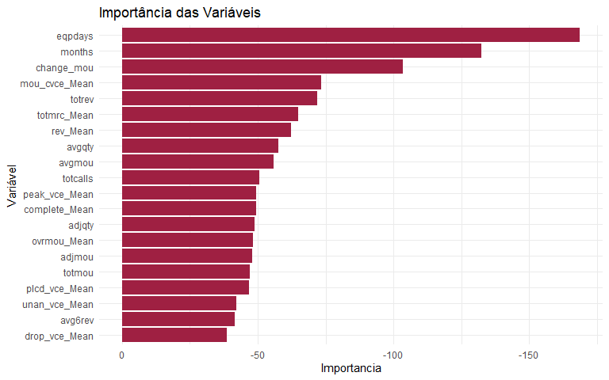

```r
# Crie um data frame com os dados
df_imp <- data.frame(
  Variaveis = rownames(imp),
  Importancia = imp[,1]
) %>% arrange(desc(Importancia))


# Crie um gráfico de barras horizontais
df_imp %>%
  ggplot(aes(y = reorder(Variaveis, -Importancia), x = Importancia)) + geom_bar(stat = "identity", fill = "#9F2042") +
  labs(title = "Importância das Variáveis",
       x = "Importancia",
       y = "Variável") +
  theme_minimal() +
  scale_x_continuous(trans = "reverse")  # Inverte a escala do eixo x (esquerda para direita)
```

A variável **Número de dias (idade) do equipamento atual** é a mais importante, seguida **Número total de meses de serviço** e **Alteração percentual nos minutos mensais de uso em relação à média dos três meses anteriores.**

### Métricas e Curva ROC

**Métricas**

```r
final_model_resul <- f_rf4(final_model)
```

```
## Precision: 0.5506857
## Recall: 0.8513661
## F1-Score: 0.6687843
## Valor do KS: 1
## AUC: 0.665698
##           Reference
## Prediction    0    1
##          0 1753  680
##          1 3178 3895
```

**Precison** é 55,06%. Isso significa que de 100 clientes que o modelo diz irem embora (churn), apenas 55 clientes realmente vão.

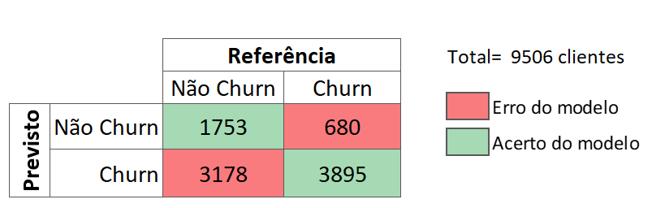

Segundo a matriz de confusão, o modelo diz que 7073 clientes vão embora. Entretanto realmente vão embora 3895. Além disso, o modelo deixou de prever o churn de 680 clientes.

**Gráfico Curva ROC**

```r
pred_final_model <- predict(final_model, newdata = dados_teste1,  type = "response")
roc_final_model <- roc(dados_teste1$churn, pred_final_model)
```

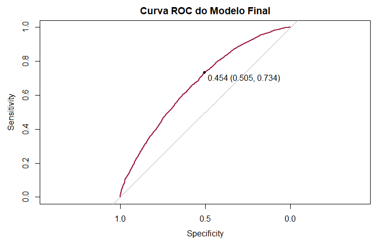

```r
par(mar = c(5, 5, 4, 2) + 0.1)  # Ajustar as margens
plot(roc_final_model, col = "#9F2042", main = "Curva ROC do Modelo Final", print.thres = T)
```

```r
#legend("bottomright", legend = c("Modelo 4"), col = c("#FF8E00"), lwd = 2)
```

# Alguns números

- Segundo o site statista, as taxas anuais de rotatividade na indústria de telecomunicações dos EUA foram de cerca de 21% em 2020 (ou 1,75% mensalmente).
- A Cell2Cell é uma das maiores empresas sem fio dos EUA, com mais de 10 milhões de clientes, e sua taxa média mensal de rotatividade é de 4% (V. UMAYAPARVATHI; K. IYAKUTTI, 2016)
- A taxa de rotatividade anual na indústria de telecomunicações varia de 20% a 40%, e o custo de reter clientes existentes é 5 a 10 vezes menor do que o custo de obtenção de novos clientes (XU; MA; KIM, 2021).
- O custo de prever a rotatividade de clientes é 16 vezes menor do que o custo de obtenção de novos clientes (XU; MA; KIM, 2021).
- Diminuir a taxa de rotatividade em 5% aumenta o lucro de 25% para 85% (XU; MA; KIM, 2021).
- Segundo uma pesquisa feita pelo site techsee, 40% dos clientes de telecomunicações afirmam que teriam mudado de ideias se lhes tivesse sido oferecido um plano de serviços melhor
- Em 2021, a receita média mensal por usuário (ARPU) gerada pelos serviços móveis sem fio nos Estados Unidos foi de 35,74 dólares americanos, segundo o site statista.

# Referências:

Customer service: churn rate by industry U.S. 2017 | Statistic.**Statista**. Disponível em: https://www.statista.com/statistics/816735/customer-churn-rate-by-industry-us/

ELLIS, C. Mtry in random forests. **Crunching the data**. 28 ago. 2022. Disponível em: https://crunchingthedata.com/mtry-in-random-forests/

ELLIS, C. Number of trees in random forests. **Crunching the data.** 27 ago. 2022. Disponível em: https://crunchingthedata.com/number-of-trees-in-random-forests/

ELLIS, C. Hyperparameter tuning in random forests. **Crunching the data**. 20 set. 2022. Disponível em: https://crunchingthedata.com/hyperparameter-tuning-in-random-forests/

PROBST, P.; BOULESTEIX, A.-L. To tune or not to tune the number of trees in random forest? Disponível em: https://arxiv.org/abs/1705.05654

PROBST, P.; WRIGHT, M. N.; BOULESTEIX, A. Hyperparameters and tuning strategies for random forest. Wiley Interdisciplinary Reviews: Data Mining and Knowledge Discovery, v. 9, n. 3, 28 jan. 2019.Disponível em: https://wires.onlinelibrary.wiley.com/doi/abs/10.1002/widm.1301

Reasons for Customer Churn in Telecoms [Survey Results]. **Techsee.** Disponível em: https://techsee.me/resources/reports/2019-telecom-churn-survey/.

SEGAL, M. R. Machine Learning Benchmarks and Random Forest Regression. Center for Bioinformatics& Molecular Biostatistics.2004.Disponível em: https://escholarship.org/uc/item/35x3v9t4

US wireless service ARPU 1993-2021. **Statista.** Disponível em: https://www.statista.com/statistics/183882/monthly-arpu-through-mobile-wireless-services-in-the-us-since-2004

V. UMAYAPARVATHI; K. IYAKUTTI. A Survey on Customer Churn Prediction in Telecom Industry: Datasets, Methods and Metrics. Disponível em: https://www.semanticscholar.org/paper/A-Survey-on-Customer-Churn-Prediction-in-Telecom-Umayaparvathi-Iyakutti/47949cd15956733c503fdb393bfb18437af1cd72

XU, T.; MA, Y.; KIM, K. Telecom Churn Prediction System Based on Ensemble Learning Using Feature Grouping. Applied Sciences, v. 11, n. 11, p. 4742, 21 maio 2021.Disponível em: https://doi.org/10.3390/app11114742